# Machine Learning Course Project

Raymond Schneider

November 19, 2016

## Introduction

This analysis seeks to take Human Activity Recognition data available at http://groupware.les.inf.puc-rio.br/har and use the data to predict errors in weight lifting technique. The data captures 5 common errors in weightlifting technique. Two models will be created and compared against known test data to determine the predictive power of each model.

## Load the Data

First we must load in the data for analysis, and load libraries we know will be used:

```r
library(caret)
library(randomForest)
library(rattle)
setwd("C:/Users/Ray/Desktop/MLCourseProject")
trainData <- read.csv("pml-training.csv")
testData <- read.csv("pml-testing.csv")
```

Next we take a look at the data. For the sake of space, we’ll not print the summary here. The data shows there are a lot of variables with NA, 0, or very few data points. We’ll need to clean this data up a bit before we build any models.

```r
summary(trainData)
```

## Data Cleaning

```r
trainNA <- sapply(trainData, function(y) sum(length(which(is.na(y)))))
trainNA <- data.frame(trainNA)
trainNA$name <- rownames(trainNA)
drops <- subset(trainNA, trainNA > 0)
drops <- as.list(drops$name)
trainNoNA <- trainData[,!(names(trainData) %in% drops)]
testNoNA <- testData[,!(names(testData) %in% drops)]
```

Next we’ll run the nearZeroVar() function in order to remove variables that have very low variance.

```r
trainNZV <- nearZeroVar(trainNoNA)
trainDataClean <- trainNoNA[,-c(trainNZV)]
testDataClean <- testNoNA[,-c(trainNZV)]
```

We’ll also remove the first six variables, as none of these are relevant to the prediction models we will create. The variables remved here are user and timestamp data.

```r
trainDataClean <- trainDataClean[,-c(1:6)]
testDataClean <- testDataClean[,-c(1:6)]
```

## Partition Training Data

Now we will take the cleaned training data, and partition to provide a training subset and testing subset, both from the original training data set.

```r
set.seed(2626)
inTrain <- createDataPartition(trainDataClean$classe, p=0.6, list=FALSE)
training <- trainDataClean[inTrain,]
testing <- trainDataClean[-inTrain,]
```

## Decision Tree Model

For our first model, we’ll attempt to fit a Classification and Regression Tree (CART) model. This appraoch was chosen as the variable we are trying to predict for is a class variable.

```r
set.seed(2626)
modelDT <- train(classe~., data=training, method="rpart")
print(modelDT, digits=5)
```

```
## CART
##
## 11776 samples
##    52 predictor
##     5 classes: 'A', 'B', 'C', 'D', 'E'
##
## No pre-processing
## Resampling: Bootstrapped (25 reps)
## Summary of sample sizes: 11776, 11776, 11776, 11776, 11776, 11776, ...
## Resampling results across tuning parameters:
##
##   cp        Accuracy  Kappa
##   0.035596  0.50577   0.354780
##   0.060592  0.44952   0.264209
##   0.117822  0.32673   0.064611
##
## Accuracy was used to select the optimal model using  the largest value.
## The final value used for the model was cp = 0.035596.
```

```r
print(modelDT$finalModel, digits=5)
```

```
## n= 11776
##
## node), split, n, loss, yval, (yprob)
##       * denotes terminal node
##
##  1) root 11776 8428 A (0.28 0.19 0.17 0.16 0.18)
##    2) roll_belt< 130.5 10773 7430 A (0.31 0.21 0.19 0.18 0.11)
##      4) pitch_forearm< -33.35 954    9 A (0.99 0.0094 0 0 0) *
##      5) pitch_forearm>=-33.35 9819 7421 A (0.24 0.23 0.21 0.2 0.12)
##       10) magnet_dumbbell_y< 439.5 8310 5954 A (0.28 0.18 0.24 0.19 0.11)
##         20) roll_forearm< 122.5 5160 3050 A (0.41 0.18 0.19 0.16 0.06) *
##         21) roll_forearm>=122.5 3150 2115 C (0.078 0.17 0.33 0.24 0.19) *
##       11) magnet_dumbbell_y>=439.5 1509  724 B (0.028 0.52 0.038 0.23 0.18) *
##    3) roll_belt>=130.5 1003    5 E (0.005 0 0 0 1) *
```

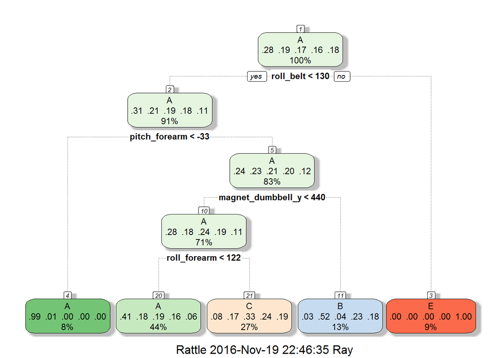

```r
fancyRpartPlot(modelDT$finalModel)
```

```r
predictDT <- predict(modelDT,testing)
confusionMatrix(testing$classe,predictDT)
```

```
## Confusion Matrix and Statistics
##
##           Reference
## Prediction    A    B    C    D    E
##          A 2025   39  159    0    9
##          B  617  501  400    0    0
##          C  625   50  693    0    0
##          D  602  218  466    0    0
##          E  216  212  381    0  633
##
## Overall Statistics
##
##                Accuracy : 0.491
##                  95% CI : (0.4798, 0.5021)
##     No Information Rate : 0.5206
##     P-Value [Acc > NIR] : 1
##
##                   Kappa : 0.3346
##  Mcnemar's Test P-Value : NA
##
## Statistics by Class:
##
##                      Class: A Class: B Class: C Class: D Class: E
## Sensitivity            0.4957  0.49118  0.33016       NA  0.98598
## Specificity            0.9450  0.85101  0.88255   0.8361  0.88770
## Pos Pred Value         0.9073  0.33004  0.50658       NA  0.43897
## Neg Pred Value         0.6331  0.91798  0.78296       NA  0.99859
## Prevalence             0.5206  0.13000  0.26752   0.0000  0.08183
## Detection Rate         0.2581  0.06385  0.08833   0.0000  0.08068
## Detection Prevalence   0.2845  0.19347  0.17436   0.1639  0.18379
## Balanced Accuracy      0.7203  0.67109  0.60635       NA  0.93684
```

## Random Forest

Next, we’ll try a random forest model. This model will take advantage of the many variables available, and may preoduve better results.

```r
set.seed(2626)
modelRF <- randomForest(classe ~ ., data=training)
print(modelRF, digits=5)
```

```
##
## Call:
##  randomForest(formula = classe ~ ., data = training)
##                Type of random forest: classification
##                      Number of trees: 500
## No. of variables tried at each split: 7
##
##         OOB estimate of  error rate: 0.69%
## Confusion matrix:
##      A    B    C    D    E  class.error
## A 3346    2    0    0    0 0.0005973716
## B   12 2259    8    0    0 0.0087757789
## C    0   19 2029    6    0 0.0121713729
## D    0    0   23 1904    3 0.0134715026
## E    0    0    2    6 2157 0.0036951501
```

This is already looking much better. Let’s extract the top variables of importance to see how they compare to the previous model. I’ve suppressed all of the variables and just output the top 7.

```r
varImp(modelRF)
```

```r
imp <- varImp(modelRF)
rownames(imp)[order(imp$Overall, decreasing=TRUE)[1:7]]
```

```
## [1] "roll_belt"         "yaw_belt"          "magnet_dumbbell_z"
## [4] "pitch_forearm"     "pitch_belt"        "magnet_dumbbell_y"
## [7] "roll_forearm"
```

These are actually quite similar to the previous model, but using more variables is increasing the predictive power of the model.

```r
predictRF <- predict(modelRF,testing)
confusionMatrix(testing$classe,predictRF)
```

```
## Confusion Matrix and Statistics
##
##           Reference
## Prediction    A    B    C    D    E
##          A 2229    2    0    0    1
##          B    8 1503    7    0    0
##          C    0    7 1359    2    0
##          D    0    0   21 1264    1
##          E    0    0    0    5 1437
##
## Overall Statistics
##
##                Accuracy : 0.9931
##                  95% CI : (0.991, 0.9948)
##     No Information Rate : 0.2851
##     P-Value [Acc > NIR] : < 2.2e-16
##
##                   Kappa : 0.9913
##  Mcnemar's Test P-Value : NA
##
## Statistics by Class:
##
##                      Class: A Class: B Class: C Class: D Class: E
## Sensitivity            0.9964   0.9940   0.9798   0.9945   0.9986
## Specificity            0.9995   0.9976   0.9986   0.9967   0.9992
## Pos Pred Value         0.9987   0.9901   0.9934   0.9829   0.9965
## Neg Pred Value         0.9986   0.9986   0.9957   0.9989   0.9997
## Prevalence             0.2851   0.1927   0.1768   0.1620   0.1834
## Detection Rate         0.2841   0.1916   0.1732   0.1611   0.1832
## Detection Prevalence   0.2845   0.1935   0.1744   0.1639   0.1838
## Balanced Accuracy      0.9979   0.9958   0.9892   0.9956   0.9989
```

The accuracy is much better, 0.99, and the model is predicting well across all of the classes of our outcome. The sensitivity, specificity, positive and megative predictive power are all high. This model is much more promising.

## Against Test Data

First, let’s test the random forest model.

```r
predictFinal <- predict(modelRF,testDataClean)
print(predictFinal)
```

```
##  1  2  3  4  5  6  7  8  9 10 11 12 13 14 15 16 17 18 19 20
##  B  A  B  A  A  E  D  B  A  A  B  C  B  A  E  E  A  B  B  B
## Levels: A B C D E
```

When comparing these results to the answers provided, the random forest model correctly predicted all 20 variables.

```r
predictFinalDT <- predict(modelDT,testDataClean)
print(predictFinal)
```

```
##  1  2  3  4  5  6  7  8  9 10 11 12 13 14 15 16 17 18 19 20
##  B  A  B  A  A  E  D  B  A  A  B  C  B  A  E  E  A  B  B  B
## Levels: A B C D E
```

## In and Out of Sample Error Rates

```r
insample <- predict(modelRF,training)
confusionMatrix(training$classe,insample)
```

```
## Confusion Matrix and Statistics
##
##           Reference
## Prediction    A    B    C    D    E
##          A 3348    0    0    0    0
##          B    0 2279    0    0    0
##          C    0    0 2054    0    0
##          D    0    0    0 1930    0
##          E    0    0    0    0 2165
##
## Overall Statistics
##
##                Accuracy : 1
##                  95% CI : (0.9997, 1)
##     No Information Rate : 0.2843
##     P-Value [Acc > NIR] : < 2.2e-16
##
##                   Kappa : 1
##  Mcnemar's Test P-Value : NA
##
## Statistics by Class:
##
##                      Class: A Class: B Class: C Class: D Class: E
## Sensitivity            1.0000   1.0000   1.0000   1.0000   1.0000
## Specificity            1.0000   1.0000   1.0000   1.0000   1.0000
## Pos Pred Value         1.0000   1.0000   1.0000   1.0000   1.0000
## Neg Pred Value         1.0000   1.0000   1.0000   1.0000   1.0000
## Prevalence             0.2843   0.1935   0.1744   0.1639   0.1838
## Detection Rate         0.2843   0.1935   0.1744   0.1639   0.1838
## Detection Prevalence   0.2843   0.1935   0.1744   0.1639   0.1838
## Balanced Accuracy      1.0000   1.0000   1.0000   1.0000   1.0000
```

The in-sample error rate is 0, which may indicate overfitting.

As indicated before, the out of sample error rate is 0.0069 (1 - accuracy).

## Conclusion

The random forest model was better able to predict the outcomes for this data set, as evidenced by all metrics observed in this analysis.